# DATA 607 – Project 2: National Grid Code Base

Author

Lakeranie Boodram

Published

October 9, 2026

## 1 Introduction

For this project, I will be working with electrical distribution data from National Grid’s New York System Data Portal.

## 2 Load Required Packages

```r
library(tidyverse)
library(knitr)
```

## 3 Import National Grid Data

In this section, I will connect to National Grid’s New York System Data Portal to identify the available data layers. This will help me locate the electrical feeder and substation information needed for my analysis.

```r
# Load package to read JSON data
library(jsonlite)

# National Grid ArcGIS data source
base_url <- paste0("https://systemdataportal.nationalgrid.com/",
"arcgis/rest/services/NYSDP/",
"DistAssetsOverview/MapServer"
)

# Retrieve information about available data layers
service_info <- jsonlite::fromJSON(
paste0(base_url, "?f=pjson")
)

# Display available layers
service_info$layers[, c("id", "name")]
```

```
  id        name
1  0 Three Phase
2  1          OH
3  2          UG
4  3      Phase1
```

## 4 Examine National Grid Data Fields

After identifying the available layers, I will examine the fields in Layer 2 to understand what information is available. I want to confirm that the dataset contains the feeder, substation, summer rating, and peak electrical demand measurements needed for my analysis.

```r
# Select Layer 2 (UG)
layer_url <- paste0(base_url, "/2")

# Retrieve layer information
layer_info <- jsonlite::fromJSON(
  paste0(layer_url, "?f=pjson")
)

# Display field names and descriptions
layer_info$fields[, c("name", "alias")]
```

```
                            name                                alias
1                       OBJECTID                             OBJECTID
2                          SHAPE                                SHAPE
3                     MASTER_CDF                               Feeder
4                  SUBSTATION_ID                        SUBSTATION_ID
5                SUBSTATION_NAME                           Substation
6              OPERATING_VOLTAGE               Operating Voltage (kV)
7          FEEDER_SN_RATING_AMPS                 Summer Rating (Amps)
8                   SHAPE_Length                         SHAPE_Length
9         PEAK_AMPS_CURRENT_YEAR                     2023 Peak (Amps)
10       PCT_RATING_CURRENT_YEAR               2023 Peak % Rating (%)
11           PEAK_AMPS_LAST_YEAR                     2022 Peak (Amps)
12          PCT_RATING_LAST_YEAR               2022 Peak % Rating (%)
13                  Construction                         Construction
14 Historical_Load_Curve_Extract Feeder Historical Load Curve Extract
15   Forecast_Load_Curve_Extract   Feeder Forecast Load Curve Extract
```

## 5 Import National Grid Records

After confirming the available fields, I will import the electrical distribution records from Layer 2 of National Grid’s data portal. I will keep the original measurements in their wide format so I can examine the data before making any changes.

```r
# Select the fields needed for the analysis
selected_fields <- c(
  "OBJECTID",
  "MASTER_CDF",
  "SUBSTATION_NAME",
  "OPERATING_VOLTAGE",
  "FEEDER_SN_RATING_AMPS",
  "PEAK_AMPS_CURRENT_YEAR",
  "PEAK_AMPS_LAST_YEAR",
  "PCT_RATING_CURRENT_YEAR",
  "PCT_RATING_LAST_YEAR"
)

# Retrieve records from the National Grid ArcGIS service
query_url <- paste0(layer_url, "/query")

national_grid_raw <- jsonlite::fromJSON(
  paste0(
    query_url,
    "?where=1%3D1",
    "&outFields=", paste(selected_fields, collapse = ","),
    "&returnGeometry=false",
    "&resultRecordCount=100",
    "&f=json"
  ),
  flatten = TRUE
)

# Check for an API error
if (!is.null(national_grid_raw$error)) {
  stop(national_grid_raw$error$message)
}

# Extract the records
national_grid <- national_grid_raw$features$attributes

# Display the number of records and columns
dim(national_grid)
```

```r
# Preview the first six records
knitr::kable(head(national_grid))
```

## 6 Check National Grid API Response

The initial import did not produce a data frame. I will examine the API response to identify why the records were not extracted correctly before continuing with the analysis.

```r
# Check the structure of the API response
class(national_grid_raw)
```

```
[1] "list"
```

```r
# Display the main sections returned by the API
names(national_grid_raw)
```

```
[1] "displayFieldName" "fieldAliases"     "fields"           "features"
```

```r
# Check whether the response contains an error
national_grid_raw$error
```

```r
# Check the structure of the returned features
str(national_grid_raw$features, max.level = 2)
```

```
'data.frame':   87 obs. of  9 variables:
 $ attributes.OBJECTID               : int  81 82 83 84 217 239 280 309 360 395 ...
 $ attributes.MASTER_CDF             : chr  "36_01_16261" "36_01_16262" "36_01_16263" "36_01_20552" ...
 $ attributes.SUBSTATION_NAME        : chr  "162 STATION 162" "162 STATION 162" "162 STATION 162" "205 ERIE DRIVE" ...
 $ attributes.OPERATING_VOLTAGE      : num  4.16 4.16 4.16 13.2 4.16 ...
 $ attributes.FEEDER_SN_RATING_AMPS  : int  266 266 266 313 300 266 256 300 247 252 ...
 $ attributes.PEAK_AMPS_CURRENT_YEAR : num  50 50 50 40.3 33 ...
 $ attributes.PEAK_AMPS_LAST_YEAR    : num  50 50 50 60 0.02 ...
 $ attributes.PCT_RATING_CURRENT_YEAR: chr  "18.8" "18.8" "18.8" "12.88" ...
 $ attributes.PCT_RATING_LAST_YEAR   : chr  "18.8" "18.8" "18.8" "19.17" ...
```

## 7 Correct the National Grid Data Import

After reviewing the API response, I found that the National Grid records were successfully retrieved, but the JSON data had already been flattened into a data frame. This caused the original extraction method to return NULL.

I will correct the extraction process by using the features data directly and removing the attributes prefix from the column names.

```r
# Extract the imported records
national_grid <- national_grid_raw$features

# Remove the attributes prefix from column names
names(national_grid) <- sub(
  "^attributes\\.",
  "",
  names(national_grid)
)

# Check the number of rows and columns
dim(national_grid)
```

```
[1] 87  9
```

```r
# Display the column names
names(national_grid)
```

```
[1] "OBJECTID"                "MASTER_CDF"
[3] "SUBSTATION_NAME"         "OPERATING_VOLTAGE"
[5] "FEEDER_SN_RATING_AMPS"   "PEAK_AMPS_CURRENT_YEAR"
[7] "PEAK_AMPS_LAST_YEAR"     "PCT_RATING_CURRENT_YEAR"
[9] "PCT_RATING_LAST_YEAR"
```

```r
# Preview the first six records
print(head(national_grid))
```

```
  OBJECTID  MASTER_CDF SUBSTATION_NAME OPERATING_VOLTAGE FEEDER_SN_RATING_AMPS
1       81 36_01_16261 162 STATION 162              4.16                   266
2       82 36_01_16262 162 STATION 162              4.16                   266
3       83 36_01_16263 162 STATION 162              4.16                   266
4       84 36_01_20552  205 ERIE DRIVE             13.20                   313
5      217  36_01_2961      29 POTOMAC              4.16                   300
6      239  36_01_3067     30 SPILLMAN              4.16                   266
  PEAK_AMPS_CURRENT_YEAR PEAK_AMPS_LAST_YEAR PCT_RATING_CURRENT_YEAR
1                  50.00            50.00000                    18.8
2                  50.00            50.00000                    18.8
3                  50.00            50.00000                    18.8
4                  40.33            60.00000                   12.88
5                  33.00             0.02000                      11
6                 100.00            66.66666                   37.59
  PCT_RATING_LAST_YEAR
1                 18.8
2                 18.8
3                 18.8
4                19.17
5                 0.01
6                25.06
```

## 8 Save the Original National Grid Dataset

Now that I have successfully imported the National Grid records, I will save the dataset in its original wide format before making any transformations. This will allow me to preserve the original structure and compare it with the cleaned dataset later.

I will also upload the CSV file to GitHub so the data can be accessed directly when running my analysis.

```r
# Save the original wide-format dataset
readr::write_csv(
  national_grid,
  "National_Grid_Original.csv"
)

# Confirm that the file was created
file.exists("National_Grid_Original.csv")
```

```
[1] TRUE
```

```r
# Display the number of rows and columns
dim(national_grid)
```

```
[1] 87  9
```

```r
# Confirm the original column names
names(national_grid)
```

```
[1] "OBJECTID"                "MASTER_CDF"
[3] "SUBSTATION_NAME"         "OPERATING_VOLTAGE"
[5] "FEEDER_SN_RATING_AMPS"   "PEAK_AMPS_CURRENT_YEAR"
[7] "PEAK_AMPS_LAST_YEAR"     "PCT_RATING_CURRENT_YEAR"
[9] "PCT_RATING_LAST_YEAR"
```

## 9 Load National Grid Data From GitHub

After uploading the original National Grid dataset to GitHub, I will import the CSV file directly using its raw GitHub URL. This will make my analysis reproducible and allow others to access the same data without needing a local file.

```r
# Import original National Grid dataset from GitHub
github_url <- "https://raw.githubusercontent.com/LBoodram26/Project-2/main/National_Grid_Original.csv"

national_grid <- readr::read_csv(
  github_url,
  show_col_types = FALSE
)

# Check dataset dimensions
dim(national_grid)
```

```
[1] 87  9
```

```r
# Display column names
names(national_grid)
```

```
[1] "OBJECTID"                "MASTER_CDF"
[3] "SUBSTATION_NAME"         "OPERATING_VOLTAGE"
[5] "FEEDER_SN_RATING_AMPS"   "PEAK_AMPS_CURRENT_YEAR"
[7] "PEAK_AMPS_LAST_YEAR"     "PCT_RATING_CURRENT_YEAR"
[9] "PCT_RATING_LAST_YEAR"
```

```r
# Preview the first six rows
print(head(national_grid))
```

```
# A tibble: 6 × 9
  OBJECTID MASTER_CDF  SUBSTATION_NAME OPERATING_VOLTAGE FEEDER_SN_RATING_AMPS
     <dbl> <chr>       <chr>                       <dbl>                 <dbl>
1       81 36_01_16261 162 STATION 162              4.16                   266
2       82 36_01_16262 162 STATION 162              4.16                   266
3       83 36_01_16263 162 STATION 162              4.16                   266
4       84 36_01_20552 205 ERIE DRIVE              13.2                    313
5      217 36_01_2961  29 POTOMAC                   4.16                   300
6      239 36_01_3067  30 SPILLMAN                  4.16                   266
# ℹ 4 more variables: PEAK_AMPS_CURRENT_YEAR <dbl>, PEAK_AMPS_LAST_YEAR <dbl>,
#   PCT_RATING_CURRENT_YEAR <dbl>, PCT_RATING_LAST_YEAR <dbl>
```

## 10 Check Data Quality

Before transforming the National Grid dataset, I will check for missing values, duplicate records, and data types. This will help me identify any issues that could affect my analysis.

I will also examine the structure of the dataset to confirm that the electrical measurements are stored correctly.

```r
# Check the structure of the dataset
str(national_grid)
```

```
spc_tbl_ [87 × 9] (S3: spec_tbl_df/tbl_df/tbl/data.frame)
 $ OBJECTID               : num [1:87] 81 82 83 84 217 239 280 309 360 395 ...
 $ MASTER_CDF             : chr [1:87] "36_01_16261" "36_01_16262" "36_01_16263" "36_01_20552" ...
 $ SUBSTATION_NAME        : chr [1:87] "162 STATION 162" "162 STATION 162" "162 STATION 162" "205 ERIE DRIVE" ...
 $ OPERATING_VOLTAGE      : num [1:87] 4.16 4.16 4.16 13.2 4.16 ...
 $ FEEDER_SN_RATING_AMPS  : num [1:87] 266 266 266 313 300 266 256 300 247 252 ...
 $ PEAK_AMPS_CURRENT_YEAR : num [1:87] 50 50 50 40.3 33 ...
 $ PEAK_AMPS_LAST_YEAR    : num [1:87] 50 50 50 60 0.02 ...
 $ PCT_RATING_CURRENT_YEAR: num [1:87] 18.8 18.8 18.8 12.9 11 ...
 $ PCT_RATING_LAST_YEAR   : num [1:87] 18.8 18.8 18.8 19.17 0.01 ...
 - attr(*, "spec")=
  .. cols(
  ..   OBJECTID = col_double(),
  ..   MASTER_CDF = col_character(),
  ..   SUBSTATION_NAME = col_character(),
  ..   OPERATING_VOLTAGE = col_double(),
  ..   FEEDER_SN_RATING_AMPS = col_double(),
  ..   PEAK_AMPS_CURRENT_YEAR = col_double(),
  ..   PEAK_AMPS_LAST_YEAR = col_double(),
  ..   PCT_RATING_CURRENT_YEAR = col_double(),
  ..   PCT_RATING_LAST_YEAR = col_double()
  .. )
 - attr(*, "problems")=<pointer: 0xc4e7b8c40>
```

```r
# Count missing values in each column
missing_values <- national_grid %>%
  summarise(across(
    everything(),
    ~ sum(is.na(.x))
  ))

print(missing_values)
```

```
# A tibble: 1 × 9
  OBJECTID MASTER_CDF SUBSTATION_NAME OPERATING_VOLTAGE FEEDER_SN_RATING_AMPS
     <int>      <int>           <int>             <int>                 <int>
1        0          0               0                 0                     0
# ℹ 4 more variables: PEAK_AMPS_CURRENT_YEAR <int>, PEAK_AMPS_LAST_YEAR <int>,
#   PCT_RATING_CURRENT_YEAR <int>, PCT_RATING_LAST_YEAR <int>
```

```r
# Check for duplicate feeder records
duplicate_feeders <- national_grid %>%
  count(MASTER_CDF) %>%
  filter(n > 1)

print(duplicate_feeders)
```

```
# A tibble: 0 × 2
# ℹ 2 variables: MASTER_CDF <chr>, n <int>
```

```r
# Check for completely duplicated rows
sum(duplicated(national_grid))
```

```
[1] 0
```

```r
# Display summary statistics
summary(national_grid)
```

```
    OBJECTID          MASTER_CDF  SUBSTATION_NAME OPERATING_VOLTAGE
 Min.   :  81.0   Length   :87   Length   :87     Min.   : 4.16
 1st Qu.: 958.5   N.unique :87   N.unique :28     1st Qu.: 4.16
 Median :1005.0   N.blank  : 0   N.blank  : 0     Median :13.20
 Mean   :1130.0   Min.nchar:10   Min.nchar: 7     Mean   :10.24
 3rd Qu.:1546.5   Max.nchar:15   Max.nchar:17     3rd Qu.:13.20
 Max.   :1887.0                                   Max.   :13.20
 FEEDER_SN_RATING_AMPS PEAK_AMPS_CURRENT_YEAR PEAK_AMPS_LAST_YEAR
 Min.   :142           Min.   :  0.0          Min.   :  0.00
 1st Qu.:266           1st Qu.: 62.5          1st Qu.: 62.08
 Median :308           Median : 99.0          Median : 96.00
 Mean   :315           Mean   :101.1          Mean   : 96.25
 3rd Qu.:356           3rd Qu.:125.0          3rd Qu.:125.67
 Max.   :495           Max.   :322.0          Max.   :266.58
 PCT_RATING_CURRENT_YEAR PCT_RATING_LAST_YEAR
 Min.   : 0.00           Min.   : 0.00
 1st Qu.:22.16           1st Qu.:19.28
 Median :30.70           Median :30.61
 Mean   :32.50           Mean   :31.16
 3rd Qu.:42.14           3rd Qu.:41.52
 Max.   :82.18           Max.   :80.69
```

## 11 Transform the Dataset From Wide to Long Format

After reviewing the data quality, I found that the dataset contains 87 records and 9 columns, with no missing values or duplicate feeder records. The numerical measurements are also stored correctly.

I will now use the pivot_longer() function from the tidyr package to transform the year-specific columns into a tidy format. Instead of keeping separate columns for 2022 and 2023, I will create a year column along with separate columns for peak amps and percent of rating.

This will make it easier to compare electrical demand across the two years while preserving the feeder and substation information.

```r
# Rename columns and keep the original dataset unchanged
national_grid_clean <- national_grid %>%
  rename(
    feeder = MASTER_CDF,
    substation = SUBSTATION_NAME,
    operating_voltage = OPERATING_VOLTAGE,
    summer_rating_amps = FEEDER_SN_RATING_AMPS,
    peak_amps_2023 = PEAK_AMPS_CURRENT_YEAR,
    peak_amps_2022 = PEAK_AMPS_LAST_YEAR,
    percent_rating_2023 = PCT_RATING_CURRENT_YEAR,
    percent_rating_2022 = PCT_RATING_LAST_YEAR
  )

# Convert yearly measurements into a tidy format
national_grid_tidy <- national_grid_clean %>%
  pivot_longer(
    cols = c(
      peak_amps_2022,
      peak_amps_2023,
      percent_rating_2022,
      percent_rating_2023
    ),
    names_to = c(".value", "year"),
    names_pattern = "(peak_amps|percent_rating)_(2022|2023)"
  ) %>%
  mutate(year = as.integer(year)) %>%
  arrange(feeder, year)

# Check the dimensions of the tidy dataset
dim(national_grid_tidy)
```

```
[1] 174   8
```

```r
# Preview the first six rows
print(head(national_grid_tidy))
```

```
# A tibble: 6 × 8
  OBJECTID feeder      substation     operating_voltage summer_rating_amps  year
     <dbl> <chr>       <chr>                      <dbl>              <dbl> <int>
1       81 36_01_16261 162 STATION 1…              4.16                266  2022
2       81 36_01_16261 162 STATION 1…              4.16                266  2023
3       82 36_01_16262 162 STATION 1…              4.16                266  2022
4       82 36_01_16262 162 STATION 1…              4.16                266  2023
5       83 36_01_16263 162 STATION 1…              4.16                266  2022
6       83 36_01_16263 162 STATION 1…              4.16                266  2023
# ℹ 2 more variables: peak_amps <dbl>, percent_rating <dbl>
```

```r
# Check the column names
names(national_grid_tidy)
```

```
[1] "OBJECTID"           "feeder"             "substation"
[4] "operating_voltage"  "summer_rating_amps" "year"
[7] "peak_amps"          "percent_rating"
```

## 12 Compare Peak Electrical Demand Between 2022 and 2023

After transforming the dataset into a tidy format, I will compare peak electrical demand between 2022 and 2023. I want to identify which feeders experienced the largest increases or decreases in electrical demand.

I will use dplyr and pivot_wider() to place the yearly peak measurements side by side for this comparison. I will then calculate the difference in peak amps between the two years.

A positive difference indicates an increase in demand, while a negative difference indicates a decrease.

```r
# Compare peak demand for each feeder between the two years
demand_changes <- national_grid_tidy %>%
  select(OBJECTID, feeder, substation, year, peak_amps) %>%
  pivot_wider(
    names_from = year,
    values_from = peak_amps,
    names_prefix = "peak_"
  ) %>%
  mutate(
    change_amps = peak_2023 - peak_2022
  ) %>%
  arrange(desc(change_amps))

# Display the largest increases in peak demand
largest_increases <- demand_changes %>%
  slice_head(n = 10)

print(largest_increases)
```

```
# A tibble: 10 × 6
   OBJECTID feeder      substation    peak_2022 peak_2023 change_amps
      <dbl> <chr>       <chr>             <dbl>     <dbl>       <dbl>
 1      998 36_11_24352 TEMPLE ST.      40.9        322         281.
 2     1000 36_11_24354 TEMPLE ST.       0          140         140
 3      309 36_01_3767  37 HUDSON AVE   15.7         94          78.3
 4      280 36_01_3471  34 BEST ST.    127.         165          37.6
 5      239 36_01_3067  30 SPILLMAN     66.7        100          33.3
 6      217 36_01_2961  29 POTOMAC       0.0200      33          33.0
 7     1004 36_11_24358 TEMPLE ST.       0           32          32
 8     1261 36_17_65146 TERMINA         73.0        102          29.0
 9     1506 36_30_16406 TRINITY        156.         176          19.8
10     1260 36_17_65145 TERMINA         62.8         80.3        17.6
```

```r
# Display the largest decreases in peak demand
largest_decreases <- demand_changes %>%
  arrange(change_amps) %>%
  slice_head(n = 10)

print(largest_decreases)
```

```
# A tibble: 10 × 6
   OBJECTID feeder      substation     peak_2022 peak_2023 change_amps
      <dbl> <chr>       <chr>              <dbl>     <dbl>       <dbl>
 1     1507 36_30_16408 TRINITY            130.       93         -37.2
 2     1518 36_30_16457 TRINITY            267.      239.        -27.3
 3     1639 36_31_09432 LIBERTY            124        97         -27
 4     1637 36_31_09427 LIBERTY            156       130         -26
 5     1640 36_31_09442 LIBERTY            147       123         -24
 6     1641 36_31_09444 LIBERTY            148       124         -24
 7       84 36_01_20552 205 ERIE DRIVE      60        40.3       -19.7
 8      418 36_01_4894  48 GELSTON         123       104         -19
 9     1636 36_31_09425 LIBERTY            158       139         -19
10     1870 36_38_07507 GLENS FALLS         73.7      54.7       -19.0
```

```r
# Summarize the number of feeders with increases or decreases
demand_summary <- demand_changes %>%
  summarise(
    increased = sum(change_amps > 0, na.rm = TRUE),
    decreased = sum(change_amps < 0, na.rm = TRUE),
    unchanged = sum(change_amps == 0, na.rm = TRUE),
    average_change_amps = mean(change_amps, na.rm = TRUE)
  )

print(demand_summary)
```

```
# A tibble: 1 × 4
  increased decreased unchanged average_change_amps
      <int>     <int>     <int>               <dbl>
1        34        34        19                4.82
```

## 13 Visualize Changes in Peak Electrical Demand

After calculating the differences in peak electrical demand, I found that 34 feeders experienced increases, 34 experienced decreases, and 19 remained unchanged between 2022 and 2023. The average change across the feeders was an increase of approximately 4.82 amps.

The largest increase occurred at Temple Street, while the largest decrease occurred at Trinity.

I will use ggplot2 to create a bar chart showing the ten feeders with the largest increases in electrical demand. This will help me visualize which feeders experienced the biggest changes between the two years.

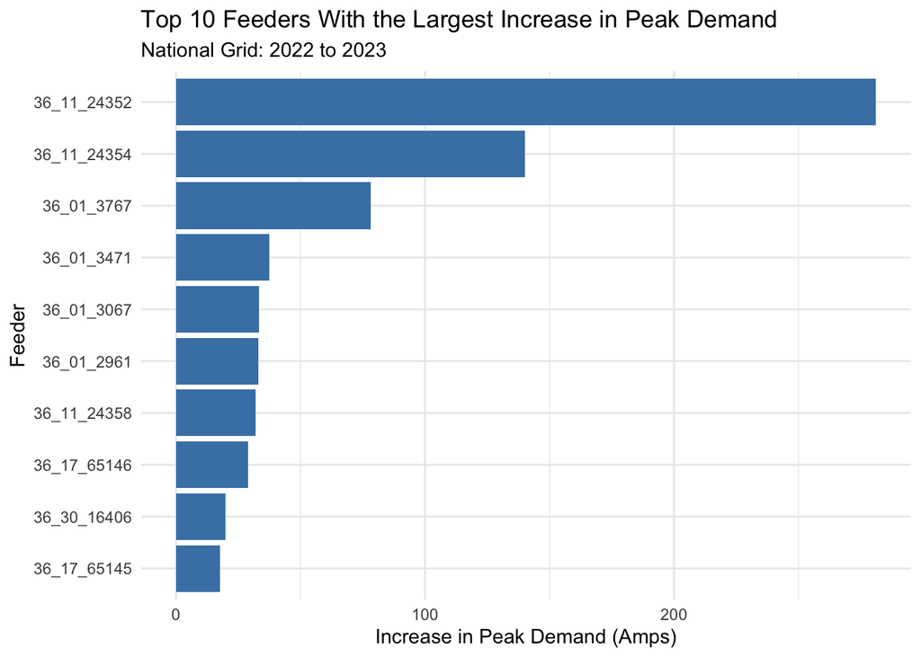

```r
# Select the ten feeders with the largest increases
top_increases <- demand_changes %>%
  slice_max(
    order_by = change_amps,
    n = 10,
    with_ties = FALSE
  )

# Create a bar chart of the largest increases
ggplot(
  top_increases,
  aes(
    x = reorder(feeder, change_amps),
    y = change_amps
  )
) +
  geom_col(fill = "steelblue") +
  coord_flip() +
  labs(
    title = "Top 10 Feeders With the Largest Increase in Peak Demand",
    subtitle = "National Grid: 2022 to 2023",
    x = "Feeder",
    y = "Increase in Peak Demand (Amps)"
  ) +
  theme_minimal()
```

## 14 Identify Feeders Operating Closest to Rated Capacity

After comparing changes in peak electrical demand, I want to examine which feeders are operating closest to their rated capacity.

I will use the percent-of-rating measurements from 2023 to identify the feeders with the highest utilization. A higher percentage indicates that a feeder’s recorded peak electrical demand was closer to its summer rating.

I will use dplyr to organize the results and ggplot2 to create a bar chart showing the ten feeders with the highest percentage of rated capacity.

```r
# Select 2023 data and identify the highest utilization
highest_utilization <- national_grid_tidy %>%
  filter(year == 2023) %>%
  filter(!is.na(percent_rating)) %>%
  arrange(desc(percent_rating)) %>%
  slice_head(n = 10)

# Display the ten feeders closest to rated capacity
print(
  highest_utilization %>%
    select(
      feeder,
      substation,
      summer_rating_amps,
      peak_amps,
      percent_rating
    )
)
```

```
# A tibble: 10 × 5
   feeder      substation   summer_rating_amps peak_amps percent_rating
   <chr>       <chr>                     <dbl>     <dbl>          <dbl>
 1 36_03_21557 BUFF AVE STA                290      238.           82.2
 2 36_11_24352 TEMPLE ST.                  430      322            74.9
 3 36_31_09456 LIBERTY                     267      194            72.7
 4 36_11_22349 ASH ST. SUB                 247      174.           70.3
 5 36_11_22354 ASH ST. SUB                 311      207.           66.7
 6 36_01_3471  34 BEST ST.                 256      165            64.4
 7 36_11_22359 ASH ST. SUB                 376      234.           62.3
 8 36_11_24342 TEMPLE ST.                  245      151.           61.8
 9 36_11_24349 TEMPLE ST.                  244      145.           59.3
10 36_30_16406 TRINITY                     318      176            55.4
```

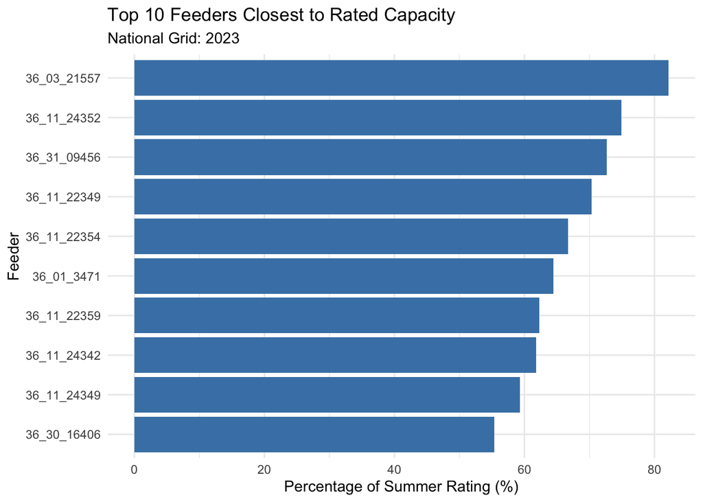

```r
# Create a bar chart of feeder utilization
ggplot(
  highest_utilization,
  aes(
    x = reorder(feeder, percent_rating),
    y = percent_rating
  )
) +
  geom_col(fill = "steelblue") +
  coord_flip() +
  labs(
    title = "Top 10 Feeders Closest to Rated Capacity",
    subtitle = "National Grid: 2023",
    x = "Feeder",
    y = "Percentage of Summer Rating (%)"
  ) +
  theme_minimal()
```

## 15 Summary of Findings

After cleaning and transforming the National Grid dataset, I was able to compare electrical demand between 2022 and 2023 across 87 feeder records. The original dataset contained separate columns for the yearly measurements, so I used pivot_longer() to create a tidy structure with separate columns for year, peak amps, and percent of rating.

The analysis showed that 34 feeders experienced an increase in peak electrical demand, 34 experienced a decrease, and 19 remained unchanged. The average change across the feeders was an increase of approximately 4.82 amps.

One finding that stood out was the Temple Street feeder, which experienced the largest increase in peak electrical demand. Its peak usage increased from approximately 40.86 amps in 2022 to 322 amps in 2023.

I also compared the feeders based on their percentage of summer-rated capacity. The Buffalo Avenue feeder had the highest recorded utilization at approximately 82.18%, followed by Temple Street at 74.88% and Liberty at 72.66%.

Overall, the analysis helped me see how electrical demand can vary between feeders and how data tidying makes it easier to compare information across different years. It also showed how using dplyr and ggplot2 can help identify changes and present the results more clearly.

## 16 Data Source and References

The original dataset was obtained from National Grid’s New York System Data Portal, using the Distribution Assets Overview ArcGIS service. For this project, I used 87 records from the UG layer, which contain feeder and substation information, summer ratings, and peak electrical demand measurements for 2022 and 2023.

The original wide-format dataset was uploaded to GitHub and imported directly into R using a raw GitHub CSV link to make the analysis reproducible.

Original dataset on GitHub: https://github.com/LBoodram26/Project-2/blob/main/National_Grid_Original.csv

References

National Grid. (n.d.). New York System Data Portal: Distribution assets overview. https://systemdataportal.nationalgrid.com/arcgis/rest/services/NYSDP/DistAssetsOverview/MapServer

Wickham, H. (2014). Tidy data. Journal of Statistical Software, 59(10), 1–23. https://doi.org/10.18637/jss.v059.i10

Wickham, H., Vaughan, D., & Girlich, M. (2024). tidyr: Tidy messy data. https://tidyr.tidyverse.org/

Wickham, H., François, R., Henry, L., Müller, K., & Vaughan, D. (2023). dplyr: A grammar of data manipulation. https://dplyr.tidyverse.org/

Wickham, H., Navarro, D., & Pedersen, T. L. (2024). ggplot2: Create elegant data visualisations using the grammar of graphics. https://ggplot2.tidyverse.org/